# Regresión Lineal Simple

## FUMADORES: COSTO vs BMI

```r
lm2 <- lm(yes$charges~yes$bmi)
summary(lm2)
```

```
##
## Call:
## lm(formula = yes$charges ~ yes$bmi)
##
## Residuals:
##      Min       1Q   Median       3Q      Max
## -19768.0  -4487.9     34.4   3263.9  31055.9
##
## Coefficients:
##              Estimate Std. Error t value Pr(>|t|)
## (Intercept) -13186.58    2052.88  -6.423 5.93e-10 ***
## yes$bmi       1473.11      65.48  22.496  < 2e-16 ***
## ---
## Signif. codes:  0 '***' 0.001 '**' 0.01 '*' 0.05 '.' 0.1 ' ' 1
##
## Residual standard error: 6837 on 272 degrees of freedom
## Multiple R-squared:  0.6504, Adjusted R-squared:  0.6491
## F-statistic: 506.1 on 1 and 272 DF,  p-value: < 2.2e-16
```

Quitando el intercepto:

```r
lm2.1 <- lm(yes$charges~ 0 + yes$bmi)
summary(lm2.1)
```

```
##
## Call:
## lm(formula = yes$charges ~ 0 + yes$bmi)
##
## Residuals:
##      Min       1Q   Median       3Q      Max
## -13492.8  -5983.4   -560.5   3936.2  30378.6
##
## Coefficients:
##         Estimate Std. Error t value Pr(>|t|)
## yes$bmi  1061.08      14.11   75.19   <2e-16 ***
## ---
## Signif. codes:  0 '***' 0.001 '**' 0.01 '*' 0.05 '.' 0.1 ' ' 1
##
## Residual standard error: 7323 on 273 degrees of freedom
## Multiple R-squared:  0.9539, Adjusted R-squared:  0.9538
## F-statistic:  5653 on 1 and 273 DF,  p-value: < 2.2e-16
```

Obtenemos un R-cuadrado del 95%¡

**RESUMEN DEL MODELO:**

**Y = 1061.08 x BMI**

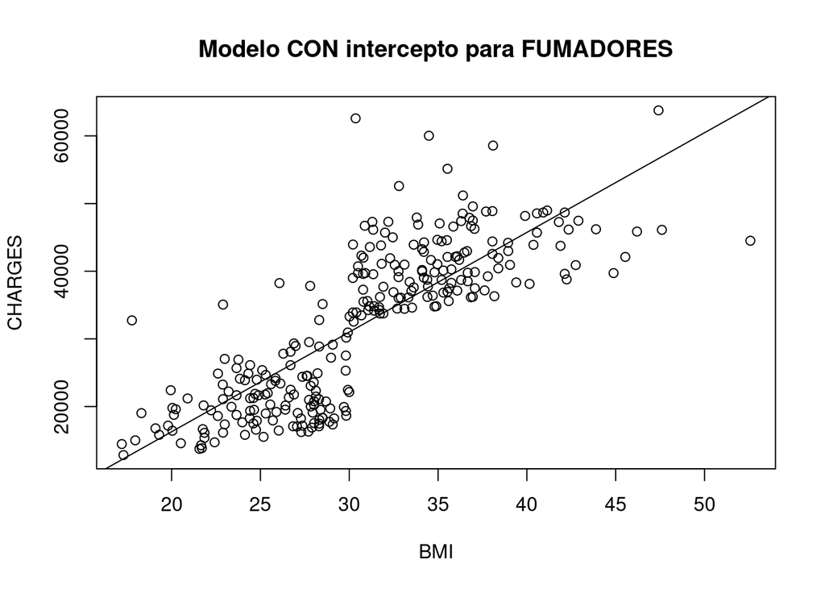

```
## integer(0)
```

```r
plot(yes$bmi, yes$charges, main = "Modelo CON intercepto para FUMADORES", xlab = 'BMI', ylab = 'CHARGES')+
abline( -13186.58,  1473.11)
```

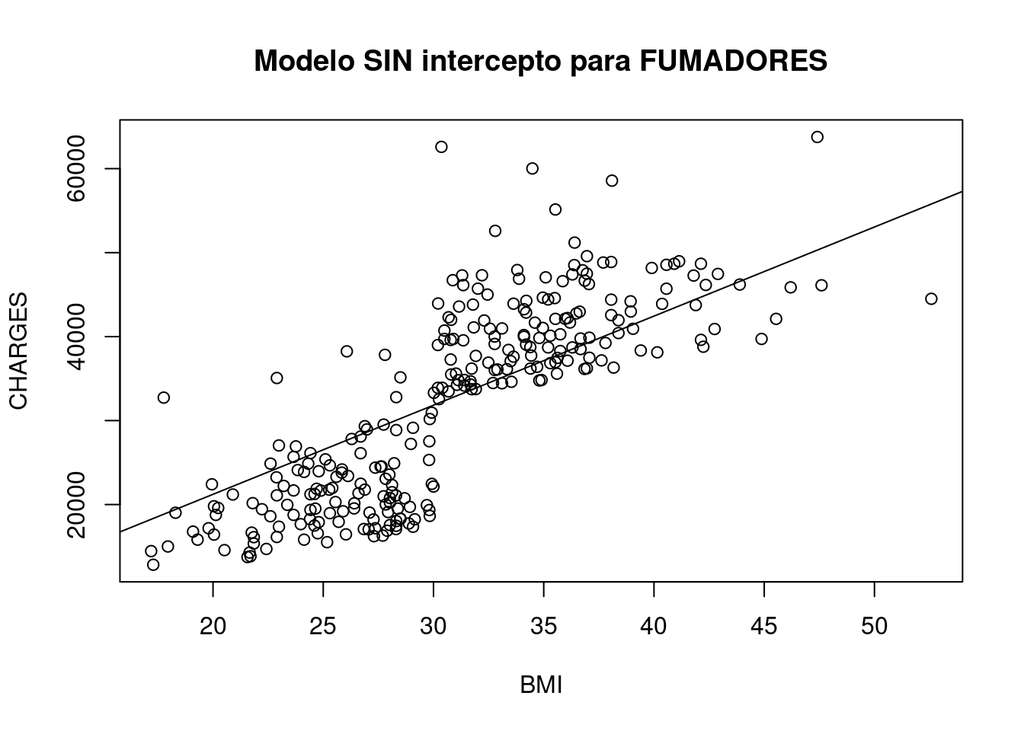

```
## integer(0)
```

```r
plot(yes$bmi, yes$charges,main = "Modelo SIN intercepto para FUMADORES", xlab = 'BMI', ylab = 'CHARGES')+
abline( 0, 1061.08)
```

### HACEMOS VERIFICACIÓN DE LOS SUPUESTOS

```r
l2res<- residuals(lm2.1)
shapiro.test(l2res)
```

```
##
##  Shapiro-Wilk normality test
##
## data:  l2res
## W = 0.97569, p-value = 0.0001279
```

```r
bptest(lm2)
```

```
##
##  studentized Breusch-Pagan test
##
## data:  lm2
## BP = 2.3496, df = 1, p-value = 0.1253
```

Podemos decir para los SI FUMADORES que en el modelo con intercepto tiene uno residuales muy pequeños y adecuados, sin embargo el intercepto es negativo y **NO EXPLICA** la realidad de que existan cobros negativos, sin embargo, para el modelo sin intercepto los residuales son mayores.

## ANÁLISIS DE VARIANZAS PARA LOS MODELOS EN GENERAL

```r
summary.aov(lm1)
```

```
##               Df    Sum Sq   Mean Sq F value Pr(>F)
## non$age        1 1.506e+10 1.506e+10   691.4 <2e-16 ***
## Residuals   1062 2.313e+10 2.178e+07
## ---
## Signif. codes:  0 '***' 0.001 '**' 0.01 '*' 0.05 '.' 0.1 ' ' 1
```

```r
summary.aov(lm1.1)
```

```
##             Df    Sum Sq   Mean Sq F value Pr(>F)
## non$age      1 9.022e+10 9.022e+10    4054 <2e-16 ***
## Residuals 1063 2.366e+10 2.226e+07
## ---
## Signif. codes:  0 '***' 0.001 '**' 0.01 '*' 0.05 '.' 0.1 ' ' 1
```

```r
summary.aov(lm2)
```

```
##              Df    Sum Sq   Mean Sq F value Pr(>F)
## yes$bmi       1 2.365e+10 2.365e+10   506.1 <2e-16 ***
## Residuals   272 1.271e+10 4.674e+07
## ---
## Signif. codes:  0 '***' 0.001 '**' 0.01 '*' 0.05 '.' 0.1 ' ' 1
```

```r
summary.aov(lm2.1)
```

```
##            Df    Sum Sq   Mean Sq F value Pr(>F)
## yes$bmi     1 3.032e+11 3.032e+11    5653 <2e-16 ***
## Residuals 273 1.464e+10 5.363e+07
## ---
## Signif. codes:  0 '***' 0.001 '**' 0.01 '*' 0.05 '.' 0.1 ' ' 1
```

## CONCLUSIÓN

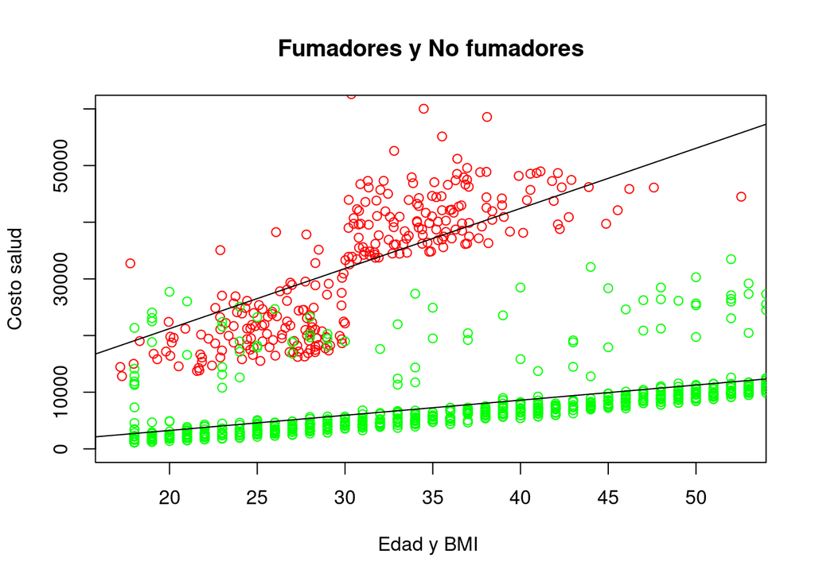

```
## integer(0)
```

```r
plot(yes$bmi,yes$charges,type="p",col="red", ylim = c(0, 60000), xlab="Edad y BMI ", ylab="Costo salud", main = 'Fumadores y No fumadores')+
lines(non$age, non$charges,type="p",col="green")+
  abline( -2091.42, 267.25)+
   abline( 0, 1061)
```

Observando las relaciones de la variable de interés con las otras variables en los diagramas y analizando su comportamiento con respecto a las variables categóricas, pudímos darnos cuenta de **relaciones lineales importantes** que nos permiten análizar por separado el problema de regresión lineal de la variable **‘charges’**.

El problema ahora sería verificar por qué los residuales de los modelos NO estan cumpliendo el supuesto de **NORMALIDAD**, tal vez haciendo una transformación adecuada de los datos para solucionarlo como una *estandarización*. Además de que tenemos el gran problema de los residuales, si observamos en cada modelo vemos que son diferentes de 0.

UNA SOLUCIÓN MÁS GENERAL sería sacar los ‘outlayers’ del modelo de AGE vs CHARGE con el fin de, obtener un mejor ajuste de los datos, que gráficamente se ven en la mayoría, suponiendo los otros datos como atípicos.